# Reproducible Research - Course project 1

Author: Joris Puttenstein

This file has been created as an assignment of the Coursera course Reproducible Research by the Johns Hopkins University.

The following script is structured using the research questions of the original assignment.

Date: 24-02-2020

#Loading and preprocessing the data

```r
activity <- read.csv("activity.csv")
```

#What is mean total number of steps taken per day?

##1. Total number of steps taken per day

```r
sum(activity$steps, na.rm = TRUE)/length(unique(activity$date))
```

```
## [1] 9354.23
```

Answer: The total number of steps taken per day is 9354.

##2. Histogram of the total number of steps taken each day

```r
library(dplyr)
```

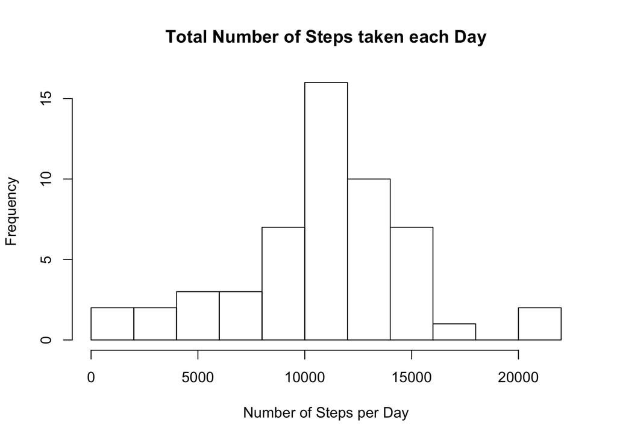

```r
by_date <- group_by(activity, date)
StepsPerDay <- summarise(by_date, sum(steps))
hist(StepsPerDay$`sum(steps)`,
     breaks = 10,
     main = "Total Number of Steps taken each Day",
     xlab = "Number of Steps per Day",
     ylab = "Frequency")
```

##3. Mean and median of the total number of steps taken per day

```r
mean(StepsPerDay$`sum(steps)`, na.rm = TRUE)
```

```
## [1] 10766.19
```

```r
median(StepsPerDay$`sum(steps)`, na.rm = TRUE)
```

```
## [1] 10765
```

#What is the average daily activity pattern?

```r
by_interval <- group_by(activity, interval)
AvgStepsPerInterval <- summarise(by_interval, mean(steps, na.rm = TRUE))
```

##1. Time series plot of the average number of steps taken

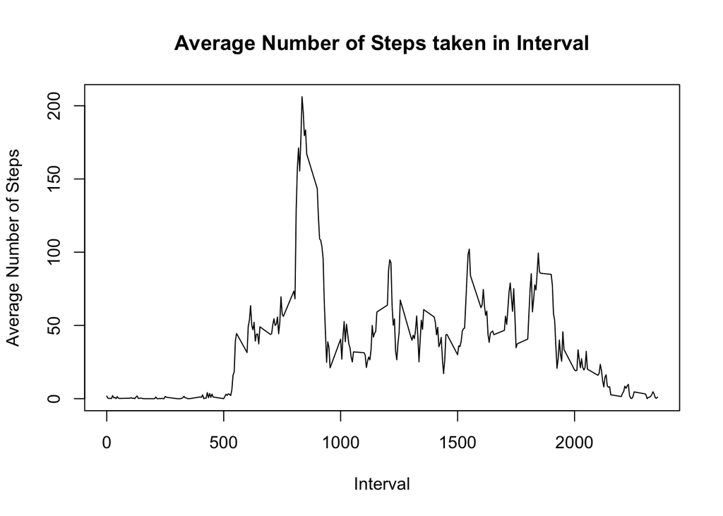

```r
plot(AvgStepsPerInterval,
    type = "l",
    main = "Average Number of Steps taken in Interval",
    xlab = "Interval",
    ylab = "Average Number of Steps")
```

##2. 5-minute interval with the maximum number of steps across all days in the dataset

```r
i_MaxAvg <- which(AvgStepsPerInterval[,2] == max(AvgStepsPerInterval[,2]))
AvgStepsPerInterval[i_MaxAvg, 1]
```

```
## # A tibble: 1 x 1
##   interval
##      <int>
## 1      835
```

#Imputing missing values

##1. Total number of missing values in the dataset

Answer: The total number of missing values in the dataset is:

```r
sum(is.na(activity$steps))
```

```
## [1] 2304
```

##2. Strategy for filling in all of the missing values in the dataset

```r
NoOfNAPerDay <- summarise(by_date, sum(is.na(steps)))
unique(NoOfNAPerDay[, 2])
```

```
## # A tibble: 2 x 1
##   `sum(is.na(steps))`
##                 <int>
## 1                 288
## 2                   0
```

```r
sum(is.na(StepsPerDay[, 2]))
```

```
## [1] 8
```

##3. Creation of new dataset that is equal to the original dataset but with the missing data filled in.

```r
activity_new <- activity
```

```r
j <- nrow(AvgStepsPerInterval)
for (i in 1:nrow(activity)) {
    activity_new[i, 1] <- ifelse(i %% j != 0,

                            ifelse(is.na(activity[i, 1]),
                                AvgStepsPerInterval[i %% j, 2],
                                activity[i, 1]),

                            ifelse(is.na(activity[i, 1]),
                                AvgStepsPerInterval[j, 2],
                                activity[i, 1]))
}
```

##4. Histogram of the total number of steps taken each day

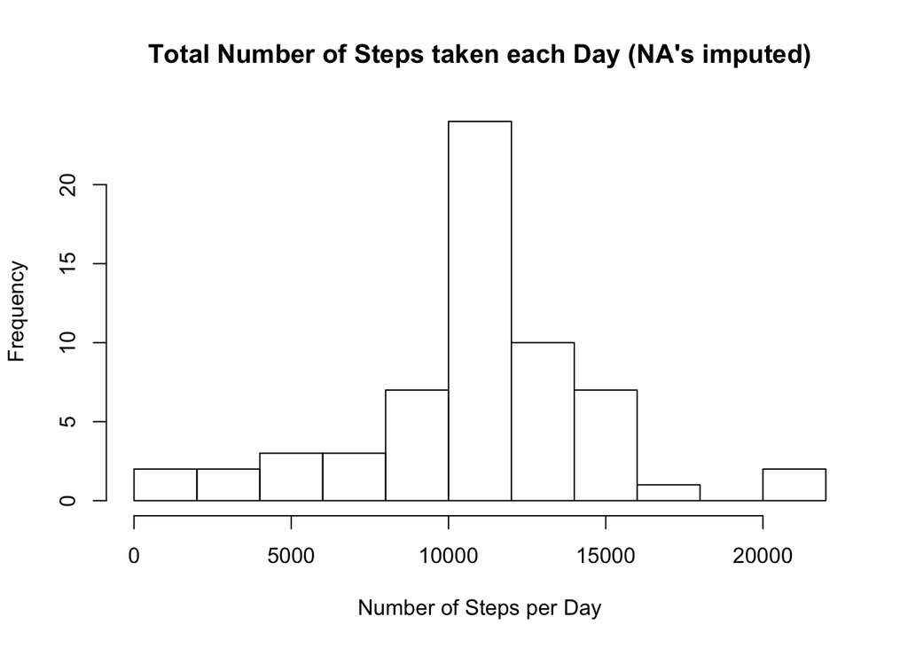

```r
by_date_new <- group_by(activity_new, date)
StepsPerDay_new <- summarise(by_date_new, sum(steps))

hist(StepsPerDay_new$`sum(steps)`,
     breaks = 10,
     main = "Total Number of Steps taken each Day (NA's imputed)",
     xlab = "Number of Steps per Day",
     ylab = "Frequency")
```

###4.1 Mean and median of total number of steps taken per day

```r
mean(StepsPerDay_new$`sum(steps)`)
```

```
## [1] 10766.19
```

```r
median(StepsPerDay_new$`sum(steps)`)
```

```
## [1] 10766.19
```

####Do these values differ from the estimates from the first part of the assignment?

The mean value is not different from the estimate from the first part of the assignment, since adding the average of a vector does not influence the average of the resulting vector.

On the other hand, the median HAS changed, since the number of days with which it is calculated is different now.

####What is the impact of imputing missing data on the estimates of the total daily number of steps?

```r
sum(activity_new$steps)/length(unique(activity_new$date))
```

```
## [1] 10766.19
```

#Are there differences in activity patterns between weekdays and weekends?

```r
activity_new$Weekday <- ifelse(as.POSIXlt(activity_new$date)$wday < 6,
                               "Weekday", "Weekend")
```

##2. Panel plot comparing the average number of steps taken per 5-minute interval across weekdays and weekends.

```r
by_interval_new <- group_by(activity_new, interval, Weekday)
AvgStepsPerInterval_new <- summarise(by_interval_new, mean(steps))
```

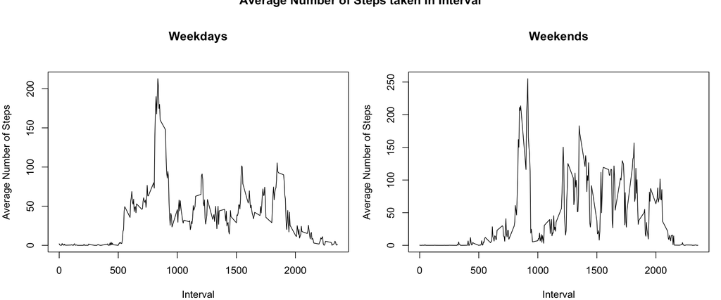

```r
par(mfrow = c(1, 2), mar = c(4, 4, 6, 1))

plot(subset(AvgStepsPerInterval_new, Weekday == "Weekday")$interval,
     subset(AvgStepsPerInterval_new, Weekday == "Weekday")$`mean(steps)`,
     type = "l",
     main = "Weekdays",
     xlab = "Interval",
     ylab = "Average Number of Steps")

plot(subset(AvgStepsPerInterval_new, Weekday == "Weekend")$interval,
     subset(AvgStepsPerInterval_new, Weekday == "Weekend")$`mean(steps)`,
     type = "l",
     main = "Weekends",
     xlab = "Interval",
     ylab = "Average Number of Steps")

title(main="Average Number of Steps taken in Interval", outer = T)
```